# Effect of Transmission Type on MPG Performance

David Garza

12/6/2020

## Model Selection Process

A correlation matrix identified possible relationships between the regressors and the response, MPG. The correlation matrix also identified possible correlations between the regressors that could create over fitting.

Several combinations of regressors were tried and evaluated by their adjusted r<sup>2</sup> scores. All of the models included transmission type and regressors that accounted for engine and car size.

The variance inflation factors were tested to see if too many variables were added and possible correlations between variables.

ANOVA testing was used on nested models to see which model added the most informative independent regressors.

The residuals, hat-values, and delta betas didn’t show anything serious problems with the winning model. The residuals are random across the measured values and no strong outliers were detected in the hat-values or delta betas.

This process is displayed in the appendix of this report.

## Model Details

The results of the model coefficients are shown below. The coefficient am1 is the additional gain in mpg of 0.15 MPG for using a manual transmission. The difference is not significant. The addition of 6 or 8 cylinders, -4.3 and -6.1 MPG respectively, is a much larger impact and is significant. The same can be said of car weight.

```
##             Estimate Std. Error t value Pr(>|t|)
## (Intercept)   33.754      2.813  11.997    0.000
## am1            0.150      1.300   0.115    0.909
## wt            -3.150      0.908  -3.469    0.002
## cyl6          -4.257      1.411  -3.017    0.006
## cyl8          -6.079      1.684  -3.611    0.001
```

## Experimental Improvements

The results may be muddled due to the confounding of car weight and engine size. The ideal case would be a pair wise experiment where each model of car has both a manual and automatic version. The cars would be tested by either the same driver, or group of drivers that is rotated among the cars to remove differences in driving style.

This experimental design would also remove the effect of car weight and engine size leaving only the effect of transmission type on MPG performance.

# Appendix

## Exploratory Analysis MPG Performance Plots

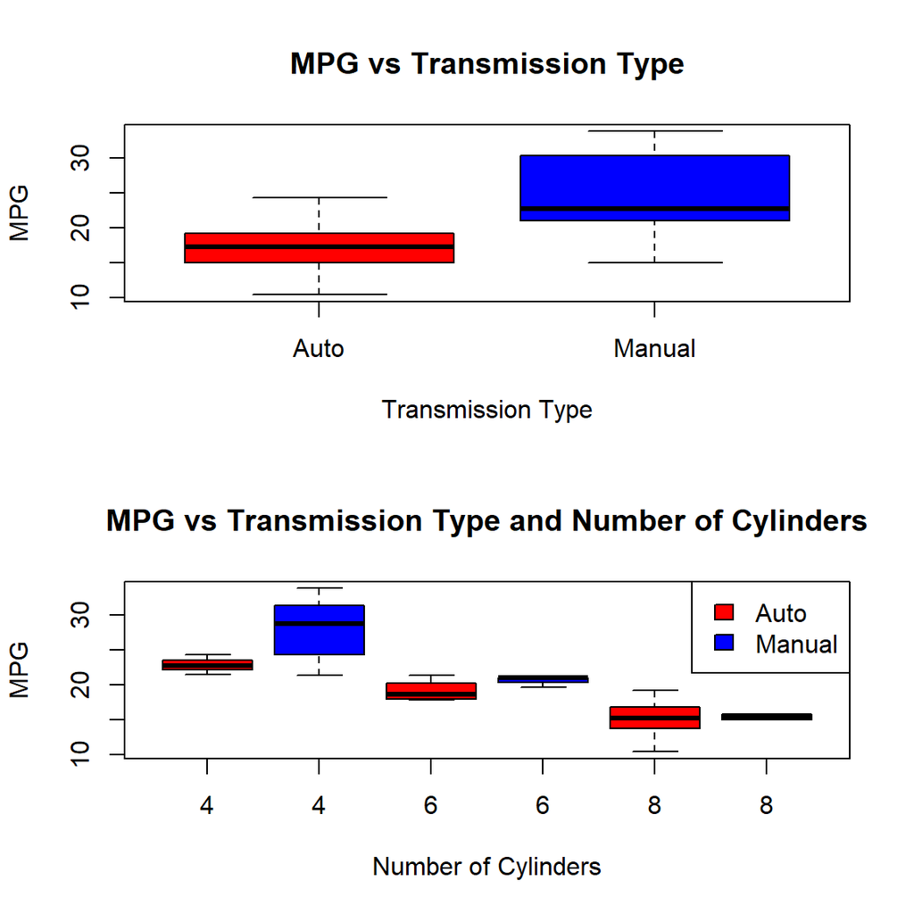

## Correlation Matrix

```
##        mpg   cyl  disp    hp  drat    wt  qsec    vs    am  gear  carb
## mpg   1.00 -0.85 -0.85 -0.78  0.68 -0.87  0.42  0.66  0.60  0.48 -0.55
## cyl  -0.85  1.00  0.90  0.83 -0.70  0.78 -0.59 -0.81 -0.52 -0.49  0.53
## disp -0.85  0.90  1.00  0.79 -0.71  0.89 -0.43 -0.71 -0.59 -0.56  0.39
## hp   -0.78  0.83  0.79  1.00 -0.45  0.66 -0.71 -0.72 -0.24 -0.13  0.75
## drat  0.68 -0.70 -0.71 -0.45  1.00 -0.71  0.09  0.44  0.71  0.70 -0.09
## wt   -0.87  0.78  0.89  0.66 -0.71  1.00 -0.17 -0.55 -0.69 -0.58  0.43
## qsec  0.42 -0.59 -0.43 -0.71  0.09 -0.17  1.00  0.74 -0.23 -0.21 -0.66
## vs    0.66 -0.81 -0.71 -0.72  0.44 -0.55  0.74  1.00  0.17  0.21 -0.57
## am    0.60 -0.52 -0.59 -0.24  0.71 -0.69 -0.23  0.17  1.00  0.79  0.06
## gear  0.48 -0.49 -0.56 -0.13  0.70 -0.58 -0.21  0.21  0.79  1.00  0.27
## carb -0.55  0.53  0.39  0.75 -0.09  0.43 -0.66 -0.57  0.06  0.27  1.00
```

## Variance Inflation Factor of Model With All Regressors

```
##  cyl disp   hp drat   wt qsec   vs   am gear carb
## 2.46 4.65 4.01 1.93 3.90 2.78 2.47 2.16 2.32 3.28
```

## Model Scoring by Adjusted R<sup>2</sup>

| model | adj.r.squared |
| --- | --- |
| cyl | 0.739944734293586 |
| drat | 0.455438627843664 |
| drat_cyl | 0.730488907093766 |
| max | 0.816480737347976 |
| min | 0.338458908206314 |
| wt | 0.735788906182185 |
| wt_cyl | 0.813440541724916 |
| wt_cyl_disp | 0.806370006989034 |
| wt_cyl_hp | 0.840087540272603 |
| wt_cyl_vs | 0.809383073729185 |

[output cut: 1 more lines]

## ANOVA Test for Bias

|  | Res.Df | RSS | Df | Sum of Sq | F | Pr(>F) |
| --- | --- | --- | --- | --- | --- | --- |
| 1 | 30 | 720.8966 | NA | NA | NA | NA |
| 2 | 29 | 278.3197 | 1 | 442.57690 | 76.192381 | 3.319656e-09 |
| 3 | 27 | 182.9683 | 2 | 95.35136 | 8.207667 | 1.725266e-03 |
| 4 | 26 | 151.0256 | 1 | 31.94274 | 5.499143 | 2.693461e-02 |

## Diagnostics for Weight and Cylinder Model

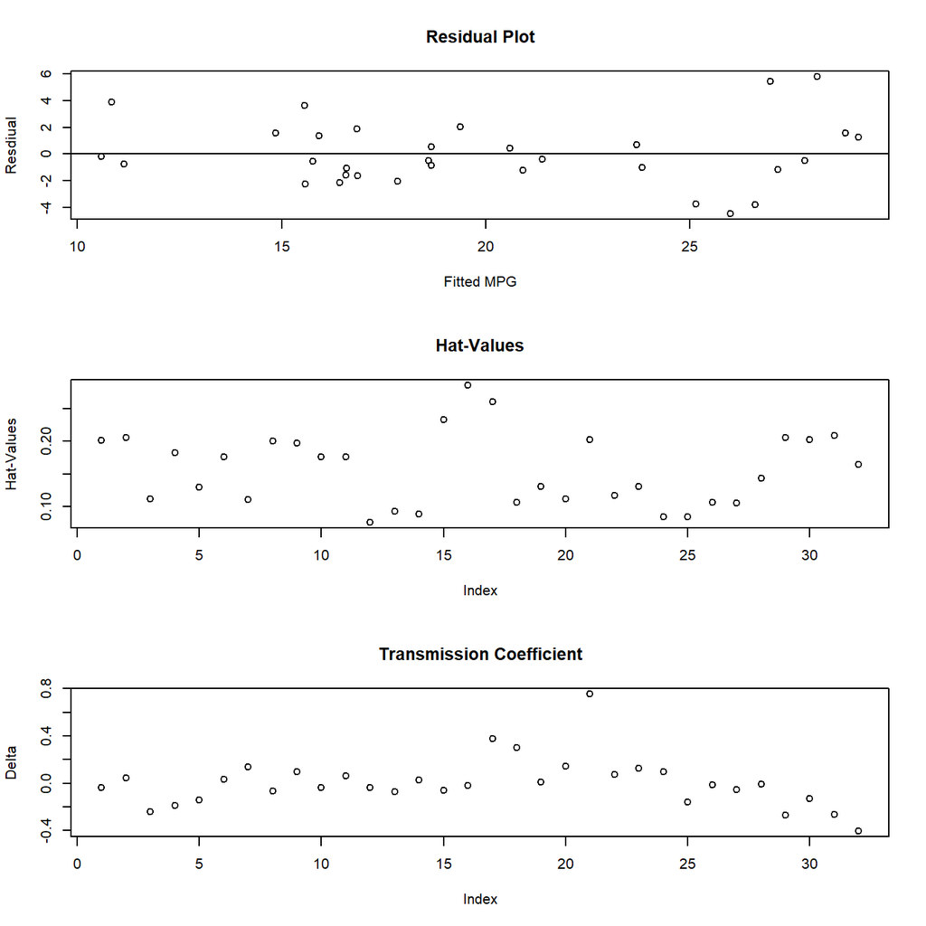